# Evaluation of the Pareto Frontier approach for model calibration

Paul Schneider, …

06 June 2021

# INTRODUCTION

This simulation study aims to compare the performance of the Pareto Frontier approach for model calibration against a distance-based summary score (selecting the 1% of inputs sets that minimise the sum of absolute differences between model outputs and calibration targets).

We conducted a simulation study, using the well-documented Sick-Sicker Model. As in the original study, three parameters were calibrated: pS1_S2, RRS1_D, and RRS2_D (see figure below and/or the `drawParams` and `runTrueMarkov` functions in `./R/functions.R`)

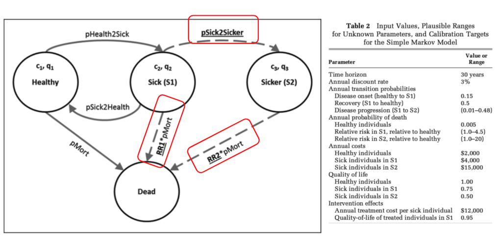

Sick-Sicker Markov Model.png

First we illustrate the methods using a single true set of parameters and assess the performance (in terms of iNMB) against a single fixed (setion 1.1) and uncertain (section 1.2) set of calibration targets.

We then expand the simulation and test the performance of the Pareto Frontier approach more systematically for any true input parameter values and across different numbers of calibration iterations and four different target sets, whereby we consider fixed (2.1) as well as stochastic target sets (2.2).

- True parameters were drawn from the following distributions:
  - pS1_S2 = random uniform 0.01-0.48
  - RRS1_D = random uniform 1, 4.5
  - RRS2_D = random uniform 1 - 20
- The number of test sets take the following values:
  - 500, 1,000, 5,000, 10,000, 20,000, 50,000
- Targets:
  - t1 = survival at year 5
  - t2 = survival at year 10
  - t3 = disease prevalence at year 5
  - t4 = sick / sicker ration at year 5
  - t5 = sick prevlanece at year 10
  - t6 = sicker prevlanece at year 10
- Target sets:
  - TS1 = {t1,t2,t3,t4}
  - TS2 = {t1, t5, t6}
  - TS3 = {t2, t5}
  - TS4 = {t1, t1, t2, t3, t5, t6}

# 0 SETUP

```r
# LOAD PACKAGES AND FUNCTIONS
library(rPref)
library(reshape2)
library(ggplot2)
library(foreach)
library(parallel)

source("./R/functions.R")
```

```r
# META PARAMS
HORIZON <- 30
DISC_RATE <- 0.03
THRESH <- 1000

set.seed(2021)
```

# 1.1 SIMULATION STUDY: SINGLE TRUE PARAMETER SET AND FIXED CALIBRATION TARGETS

This analysis aims to provide some intuition for the simulation analysis. It shows the computation for a single case, with a fixed set of true model parameters and corresponding calibration targets. It closely mirrors the original study by Enns et al. (2015).

```r
# Number of candidate input sets being evaluated
  n_calib <- 10000

# true markov model with fixed parameters
  true_params <- drawParams(pS1_S2 = 0.02, RRS1_D = 3, RRS2_D = 15)
  true_model <- runTrueMarkov(params = true_params[1,], return_targets = T)
  # corresponding true inmb
  true_inmb <- true_model$ce_res[4]


# Derive true caloibration targets (without uncertainty)
  target_set <- true_model$targets    # True targets
  target_set[1:4]
```

```
## [1]  0.9662136  0.9252154  0.2331344 15.2496760
```

```r
# run calibration and estimate iNMB
  # draw random test params
  test_params <- drawParams(
    pS1_S2 = runif(n_calib, 0.01, 0.48),
    RRS1_D =  runif(n_calib, 1, 4.5),
    RRS2_D = runif(n_calib, 1, 20)
    )

  # run model for all random param sets and compre to targets
  calib_res <- runCalibration(
    params = test_params,
    targets = target_set,
    RUNS = n_calib
    )

  # evaluate target achievement and select winning param sets
  selected_sets <- evalTargets(target_diff = calib_res$res_mat)

  # retrieve results over selected param sets
  res_list <- evalRes(selected_sets, test_params, true_inmb)

  # number of paremter sets selected
  table(res_list$res_df$L1)
```

```
##
##      pareto  sum_pareto sum_percent
##          21          21         100
```

```r
  # true inmb
  true_inmb
```

```
##     nmb
## 23068.8
```

```r
  # estimated inb and abs error
  res_list$inmb_df
```

```
##            L1     inmb inmb_error inmb_error_abs pareto_diff
## 1      pareto 13847.91 -9220.8874       9755.700       0.000
## 2  sum_pareto 22029.38 -1039.4202       1336.645   -8419.054
## 3 sum_percent 22225.78  -843.0131       1204.512   -8551.188
```

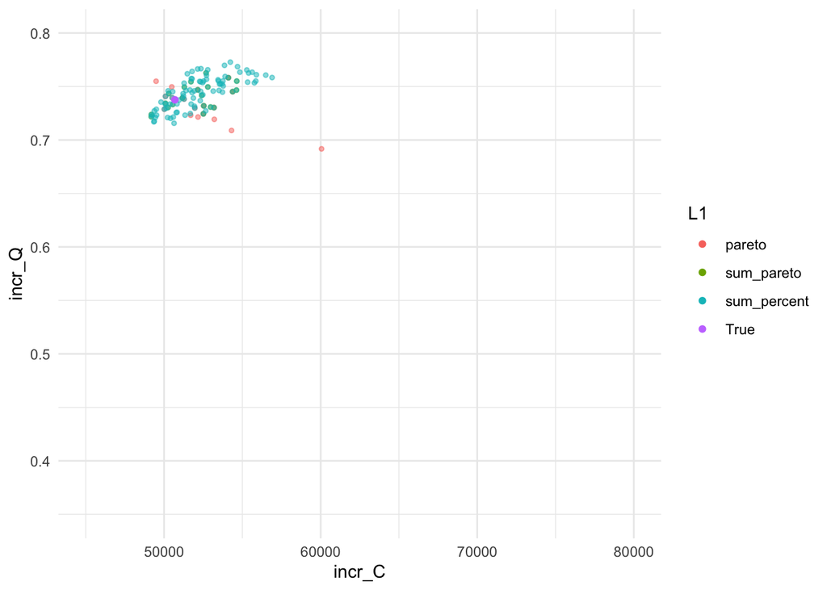

```r
  # ICER plane
  ggplot() +
    geom_point(
      data = res_list$res_df,
      aes(x = incr_C, y = incr_Q, col = L1),
      alpha = 0.5, size = 1
      ) +
    geom_point(
      aes(
        x = true_model$ce_res["incr_C"],
        y = true_model$ce_res["incr_Q"],
        col = "True"
        ), alpha = 2
      ) +
    xlim(c(45000, 80000)) +
    ylim(c(0.35, 0.8)) +
    theme_minimal()
```

# 1.2 SIMULATION STUDY: SINGLE TRUE PARAMETER SET AND (SINGLE) UNCERTAIN CALIBRATION TARGETS

Same as above with micro simulation to generate stochastic calibration targets.

```r
# Number of candidate input sets being evaluated
  n_calib <- 10000

# true markov model with fixed parameters
  true_params <- drawParams(pS1_S2 = 0.02, RRS1_D = 3, RRS2_D = 15)
  true_model <- runTrueMarkov(params = true_params[1,], return_targets = T)
  # corresponding true inmb
  true_inmb <- true_model$ce_res[4]


# Derive true caloibration targets (without uncertainty)
  target_set <- simStudy(n = 1000, true_params = true_params[1,]) #micro sim
  target_set[1:4]
```

```
## [1] 0.9640000 0.9280000 0.2284483 2.7283555
```

```r
# run calibration and estimate iNMB
  # draw random test params
  test_params <- drawParams(
    pS1_S2 = runif(n_calib, 0.01, 0.48),
    RRS1_D =  runif(n_calib, 1, 4.5),
    RRS2_D = runif(n_calib, 1, 20)
    )

  # run model for all random param sets and compre to targets
  calib_res <- runCalibration(
    params = test_params,
    targets = target_set,
    RUNS = n_calib
    )

  # evaluate target achievement and select winning param sets
  selected_sets <- evalTargets(target_diff = calib_res$res_mat)

  # retrieve results over selected param sets
  res_list <- evalRes(selected_sets, test_params, true_inmb)

  # number of paremter sets selected
  table(res_list$res_df$L1)
```

```
##
##      pareto  sum_pareto sum_percent
##         974         974         100
```

```r
  # true inmb
  true_inmb
```

```
##     nmb
## 23068.8
```

```r
  # estimated inb and abs error
  res_list$inmb_df
```

```
##            L1      inmb inmb_error inmb_error_abs pareto_diff
## 1      pareto  6131.849  -16936.95       17212.01        0.00
## 2  sum_pareto -9432.476  -32501.27       32501.27    15289.27
## 3 sum_percent -9202.755  -32271.55       32271.55    15059.55
```

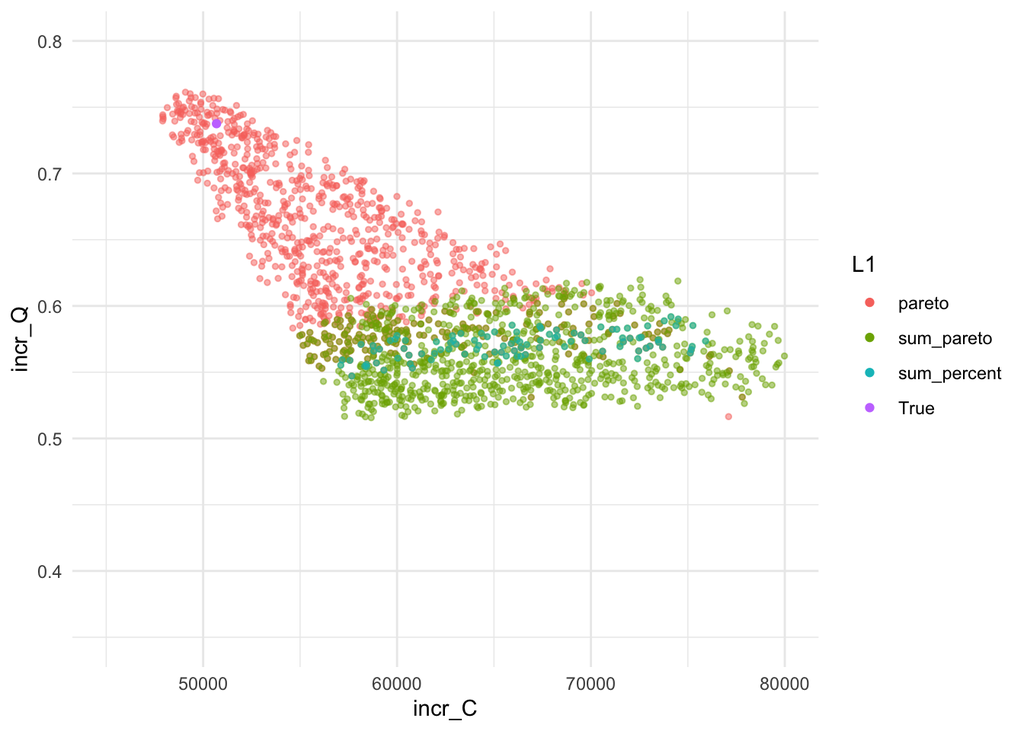

```r
  # ICER plane
  ggplot() +
    geom_point(
      data = res_list$res_df,
      aes(x = incr_C, y = incr_Q, col = L1),
      alpha = 0.5, size = 1
      ) +
    geom_point(
      aes(
        x = true_model$ce_res["incr_C"],
        y = true_model$ce_res["incr_Q"],
        col = "True"
        ), alpha = 2
      ) +
    xlim(c(45000, 80000)) +
    ylim(c(0.35, 0.8)) +
    theme_minimal()
```

# 2.1 SIMULATION STUDY: RANDOM PARAMETER SETS AND FIXED CALIBRATION TARGETS

Analysis steps in short:

1. Randomly draw 10,000 sets of true parameters
2. Compute true inmb and derive fixed calibration targets
3. run model calibration with 500, 1,000, …, 50,000 test parameter sets
4. Evaluate target fits and select best fitting sets
5. Compare estimated and true inmb and parameter values

## RUN SIMULATION

Consider running this in parallel in the cloud - otherwise, this may take >24h to run.

## ANALYSE RESULTS

### RE-ARRANGE THE DATA

```r
# load simulation results
res_mat <- data.frame(readRDS("./output/res_fixed.RDS"))
# re-format
for(i in c(1,3:ncol(res_mat))){
  res_mat[,i] <- as.numeric(res_mat[,i])
}

names(res_mat) <- c(
  "run","method","inmb","inmb_error","inmb_error_abs","pareto_diff",
  "pS1_S2_diff", "RRS1_D_diff", "RRS2_D_diff","run2",
  "n_calib","pareto_n","n_study_size","true_inmb"
  )
res_mat$target_set <- rep(c(1,2,3,4), each = 3) # forgot to specify this previously

res_mat <- res_mat[res_mat$method %in% c("pareto", "sum_percent"),]
dim(res_mat)
```

```
## [1] 480000     15
```

```r
head(res_mat)
```

```
##   run      method      inmb inmb_error inmb_error_abs pareto_diff   pS1_S2_diff
## 1   1      pareto -30842.37 -8115.0848       9310.131       0.000  3.525884e-02
## 3   1 sum_percent -22551.84   175.4498       1830.621   -7479.510 -8.716814e-05
## 4   1      pareto -31552.69 -8825.4008       9584.031       0.000  3.863675e-02
## 6   1 sum_percent -23245.88  -518.5938       1581.032   -8003.000 -5.036070e-03
## 7   1      pareto -31274.04 -8546.7580       8595.584       0.000  1.915449e-02
## 9   1 sum_percent -21464.51  1262.7810       1262.781   -7332.803 -3.340701e-03
##   RRS1_D_diff RRS2_D_diff run2 n_calib pareto_n n_study_size true_inmb
## 1 -0.54948140  -2.6591060    1     500       13           NA -22727.29
## 3  0.16236510   0.1944475    1     500       13           NA -22727.29
## 4 -0.45180300  -3.2627796    1     500        9           NA -22727.29
## 6  0.17680380  -0.8872276    1     500        9           NA -22727.29
## 7 -0.89001917  -4.2606355    1     500        4           NA -22727.29
## 9  0.07149088   0.6632607    1     500        4           NA -22727.29
##   target_set
## 1          1
## 3          1
## 4          2
## 6          2
## 7          3
## 9          3
```

```r
# relative performance of pareto vs sum
pareto_diff_abs <- res_mat$inmb_error_abs[res_mat$method == "pareto"] - res_mat$inmb_error_abs[res_mat$method == "sum_percent"]

pareto_params_diff_abs <- abs(res_mat[res_mat$method == "pareto", c("pS1_S2_diff", "RRS1_D_diff", "RRS2_D_diff")]) - abs(res_mat[res_mat$method == "sum_percent", c("pS1_S2_diff", "RRS1_D_diff", "RRS2_D_diff")])
names(pareto_params_diff_abs)<-paste0("pareto_", names(pareto_params_diff_abs))
overall_diff_df <- res_mat[res_mat$method == "pareto",]
overall_diff_df$pareto_diff_abs <- pareto_diff_abs
overall_diff_df <- cbind(overall_diff_df,pareto_params_diff_abs)


# ref: calib 50,000
ref_df <- subset(res_mat, n_calib == 50000)
```

### incrmenetal net monetary benefit - absolute error

```r
# incr NMB --------
aggregate(inmb_error_abs ~ method + target_set, ref_df, aggFormat, show_range = T)
```

```
##        method target_set inmb_error_abs.mean (SD) inmb_error_abs.range
## 1      pareto          1            9,702 (4,784)        [776; 32,904]
## 2 sum_percent          1            3,787 (1,488)        [831; 10,525]
## 3      pareto          2            4,749 (2,468)        [425; 24,752]
## 4 sum_percent          2            2,940 (1,255)         [738; 8,017]
## 5      pareto          3            6,470 (4,373)        [299; 39,916]
## 6 sum_percent          3              2,432 (597)       [1,241; 7,189]
## 7      pareto          4            7,592 (3,543)      [1,000; 29,721]
## 8 sum_percent          4              2,080 (648)         [985; 7,036]
```

```r
aggregate(pareto_diff_abs ~ n_calib + target_set, overall_diff_df[overall_diff_df$n_calib == 50000,], aggFormat, show_range = T)
```

```
##   n_calib target_set pareto_diff_abs.mean (SD) pareto_diff_abs.range
## 1   50000          1             5,915 (4,451)      [-1,835; 31,930]
## 2   50000          2             1,809 (2,172)      [-2,643; 23,686]
## 3   50000          3             4,037 (4,204)      [-3,657; 38,081]
## 4   50000          4             5,513 (3,232)        [-332; 28,425]
```

```r
# by n_calib
aggregate(inmb_error_abs ~ method+n_calib + target_set, res_mat, aggFormat, show_range = T)
```

```
##         method n_calib target_set inmb_error_abs.mean (SD) inmb_error_abs.range
## 1       pareto     500          1           14,838 (7,431)        [905; 65,622]
## 2  sum_percent     500          1            3,959 (2,128)        [268; 18,753]
## 3       pareto    1000          1           13,940 (6,956)      [1,226; 63,246]
## 4  sum_percent    1000          1            3,874 (1,811)        [386; 14,260]
## 5       pareto    5000          1           11,971 (5,977)        [948; 54,706]
## 6  sum_percent    5000          1            3,803 (1,550)        [732; 12,259]
## 7       pareto   10000          1           11,240 (5,572)        [993; 47,301]
## 8  sum_percent   10000          1            3,796 (1,517)        [668; 11,233]
## 9       pareto   20000          1           10,504 (5,226)      [1,132; 41,723]
## 10 sum_percent   20000          1            3,789 (1,495)        [780; 10,846]
## 11      pareto   50000          1            9,702 (4,784)        [776; 32,904]
## 12 sum_percent   50000          1            3,787 (1,488)        [831; 10,525]
## 13      pareto     500          2            9,268 (5,428)         [14; 58,171]
## 14 sum_percent     500          2            3,062 (1,695)        [168; 12,888]
```

[output cut: 34 more lines]

```r
aggregate(pareto_diff_abs ~ n_calib + target_set, overall_diff_df, aggFormat, show_range = T)
```

```
##    n_calib target_set pareto_diff_abs.mean (SD) pareto_diff_abs.range
## 1      500          1            10,880 (7,266)      [-6,848; 60,326]
## 2     1000          1            10,066 (6,740)      [-1,726; 58,010]
## 3     5000          1             8,167 (5,680)      [-3,404; 47,951]
## 4    10000          1             7,444 (5,250)      [-2,317; 42,842]
## 5    20000          1             6,714 (4,902)      [-2,868; 37,623]
## 6    50000          1             5,915 (4,451)      [-1,835; 31,930]
## 7      500          2             6,206 (5,217)      [-3,996; 56,953]
## 8     1000          2             5,319 (4,552)      [-2,184; 43,061]
## 9     5000          2             3,608 (3,412)      [-2,665; 35,797]
## 10   10000          2             3,037 (2,974)      [-2,933; 32,385]
## 11   20000          2             2,455 (2,596)      [-2,779; 28,425]
## 12   50000          2             1,809 (2,172)      [-2,643; 23,686]
## 13     500          3             7,332 (6,671)      [-3,538; 72,134]
## 14    1000          3             6,700 (6,235)      [-3,079; 64,396]
## 15    5000          3             5,425 (5,336)      [-3,667; 48,062]
## 16   10000          3             4,948 (4,928)      [-2,906; 43,932]
## 17   20000          3             4,547 (4,631)      [-3,151; 36,650]
## 18   50000          3             4,037 (4,204)      [-3,657; 38,081]
## 19     500          4            11,125 (6,426)         [-66; 63,461]
## 20    1000          4            10,090 (5,796)        [-380; 60,339]
## 21    5000          4             7,839 (4,564)         [237; 44,928]
## 22   10000          4             7,052 (4,082)        [-276; 35,809]
## 23   20000          4             6,312 (3,702)         [-72; 36,237]
## 24   50000          4             5,513 (3,232)        [-332; 28,425]
```

```r
# true incr nmb
mean(ref_df$true_inmb); sd(ref_df$true_inmb)
```

```
## [1] -33534.43
```

```
## [1] 27123.7
```

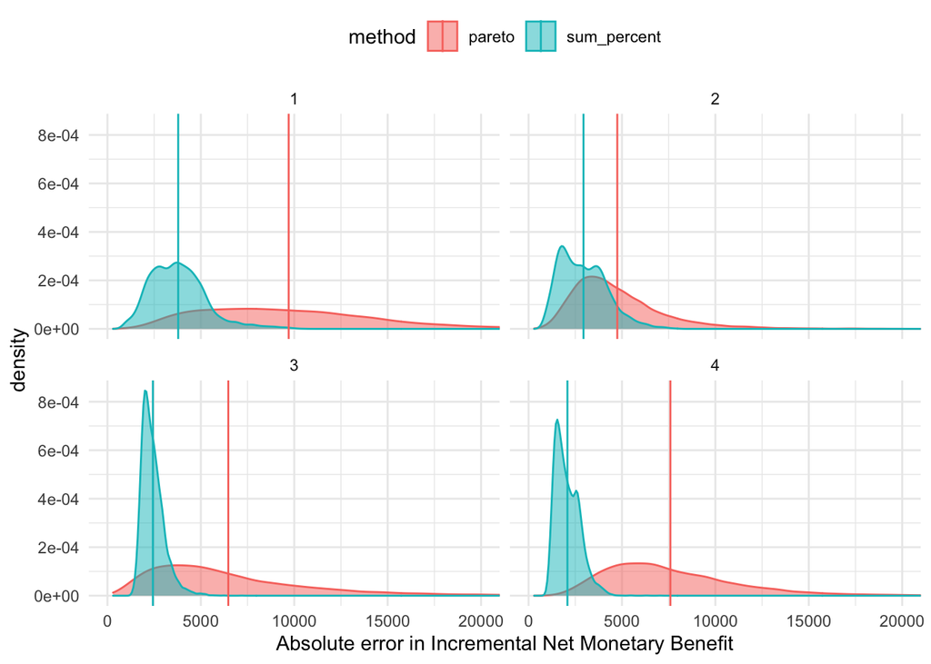

```r
# plot 1: abs error for n_calib = 50,000
inmb_error_abs_means <- aggregate(inmb_error_abs ~method+target_set,ref_df,mean )
ggplot(ref_df) +
  geom_density(aes(x = inmb_error_abs,col = method,fill = method), alpha = 0.5, position = "identity") +
  geom_vline(data = inmb_error_abs_means, aes(xintercept = inmb_error_abs, col = method)) +
  facet_wrap(~target_set) +
  coord_cartesian(xlim = c(0, 20000)) +
  xlab("Absolute error in Incremental Net Monetary Benefit") +
  theme_minimal() +
  theme(legend.position = "top")
```

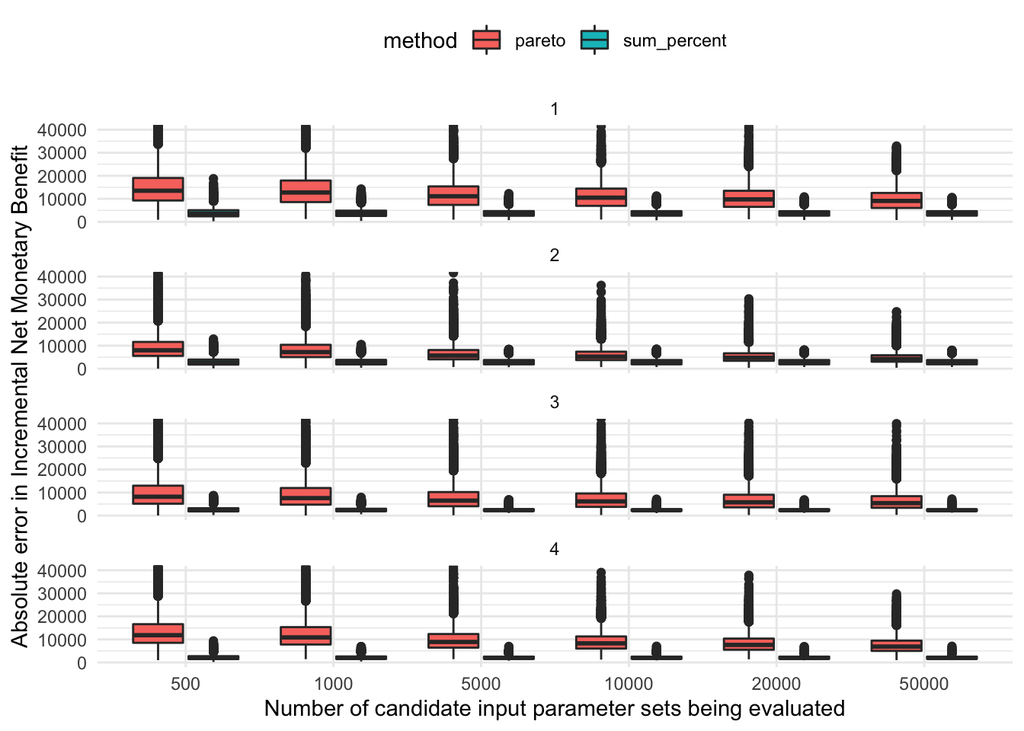

```r
# plot 2: abs error by n_calib
ggplot(res_mat) +
  geom_boxplot(aes(y=inmb_error_abs, x = as.factor(n_calib), fill = method)) +
  facet_wrap(~target_set, ncol = 1) +
  ylab("Absolute error in Incremental Net Monetary Benefit") +
  xlab("Number of candidate input parameter sets being evaluated") +
  theme_minimal() +
  coord_cartesian(ylim=c(0,40000)) +
  theme(legend.position = "top")
```

### calibration parameters - absolute error

```r
# params abs error --------
aggregate(abs(cbind(pS1_S2_diff,RRS1_D_diff,RRS2_D_diff)) ~ method + target_set, ref_df, aggFormat, digits = 3)
```

```
##        method target_set   pS1_S2_diff   RRS1_D_diff   RRS2_D_diff
## 1      pareto          1 0.100 (0.060) 0.826 (0.509) 7.557 (4.169)
## 2 sum_percent          1 0.119 (0.070) 0.804 (0.137) 7.382 (3.980)
## 3      pareto          2 0.113 (0.066) 0.824 (0.426) 7.440 (4.026)
## 4 sum_percent          2 0.118 (0.069) 0.803 (0.331) 7.395 (4.138)
## 5      pareto          3 0.109 (0.064) 0.826 (0.410) 7.460 (4.267)
## 6 sum_percent          3 0.118 (0.069) 0.822 (0.314) 7.504 (4.833)
## 7      pareto          4 0.106 (0.062) 0.818 (0.464) 7.495 (3.867)
## 8 sum_percent          4 0.119 (0.070) 0.814 (0.329) 7.451 (4.674)
```

```r
aggregate(cbind(pareto_pS1_S2_diff,pareto_RRS1_D_diff,pareto_RRS2_D_diff) ~ method + target_set, overall_diff_df[overall_diff_df$n_calib == 50000,], aggFormat, digits = 3)
```

```
##   method target_set pareto_pS1_S2_diff pareto_RRS1_D_diff pareto_RRS2_D_diff
## 1 pareto          1     -0.018 (0.024)      0.022 (0.444)      0.175 (1.479)
## 2 pareto          2     -0.005 (0.010)      0.021 (0.205)      0.045 (0.880)
## 3 pareto          3     -0.010 (0.019)      0.004 (0.299)     -0.044 (1.326)
## 4 pareto          4     -0.012 (0.016)      0.004 (0.232)      0.044 (1.188)
```

```r
# by n_calib
aggregate(abs(cbind(pS1_S2_diff,RRS1_D_diff,RRS2_D_diff)) ~ method + n_calib + target_set, res_mat, aggFormat, digits = 3)
```

```
##         method n_calib target_set   pS1_S2_diff   RRS1_D_diff   RRS2_D_diff
## 1       pareto     500          1 0.090 (0.055) 0.814 (0.394) 7.609 (3.471)
## 2  sum_percent     500          1 0.119 (0.070) 0.812 (0.435) 7.381 (4.203)
## 3       pareto    1000          1 0.091 (0.056) 0.814 (0.411) 7.586 (3.605)
## 4  sum_percent    1000          1 0.119 (0.070) 0.800 (0.333) 7.379 (4.084)
## 5       pareto    5000          1 0.095 (0.057) 0.819 (0.455) 7.571 (3.893)
## 6  sum_percent    5000          1 0.119 (0.070) 0.806 (0.191) 7.376 (3.999)
## 7       pareto   10000          1 0.097 (0.058) 0.820 (0.471) 7.560 (3.986)
## 8  sum_percent   10000          1 0.119 (0.070) 0.805 (0.164) 7.379 (3.987)
## 9       pareto   20000          1 0.099 (0.059) 0.824 (0.489) 7.551 (4.075)
## 10 sum_percent   20000          1 0.119 (0.070) 0.805 (0.148) 7.380 (3.983)
## 11      pareto   50000          1 0.100 (0.060) 0.826 (0.509) 7.557 (4.169)
## 12 sum_percent   50000          1 0.119 (0.070) 0.804 (0.137) 7.382 (3.980)
## 13      pareto     500          2 0.105 (0.061) 0.825 (0.423) 7.452 (3.322)
## 14 sum_percent     500          2 0.118 (0.070) 0.822 (0.481) 7.414 (4.302)
```

[output cut: 34 more lines]

```r
aggregate(cbind(pareto_pS1_S2_diff,pareto_RRS1_D_diff,pareto_RRS2_D_diff) ~ n_calib + target_set, overall_diff_df, aggFormat, digits = 3)
```

```
##    n_calib target_set pareto_pS1_S2_diff pareto_RRS1_D_diff pareto_RRS2_D_diff
## 1      500          1     -0.029 (0.039)      0.002 (0.476)      0.228 (2.178)
## 2     1000          1     -0.027 (0.036)      0.014 (0.422)      0.207 (1.854)
## 3     5000          1     -0.023 (0.031)      0.013 (0.402)      0.195 (1.518)
## 4    10000          1     -0.022 (0.028)      0.015 (0.411)      0.181 (1.464)
## 5    20000          1     -0.020 (0.026)      0.018 (0.425)      0.172 (1.461)
## 6    50000          1     -0.018 (0.024)      0.022 (0.444)      0.175 (1.479)
## 7      500          2     -0.013 (0.027)      0.002 (0.377)      0.038 (2.051)
## 8     1000          2     -0.011 (0.023)      0.017 (0.310)      0.021 (1.743)
## 9     5000          2     -0.008 (0.017)      0.018 (0.236)      0.039 (1.231)
## 10   10000          2     -0.007 (0.014)      0.017 (0.219)      0.056 (1.102)
## 11   20000          2     -0.006 (0.013)      0.018 (0.209)      0.055 (0.985)
## 12   50000          2     -0.005 (0.010)      0.021 (0.205)      0.045 (0.880)
## 13     500          3     -0.015 (0.032)     -0.009 (0.422)     -0.044 (2.109)
## 14    1000          3     -0.014 (0.030)      0.008 (0.384)     -0.047 (1.949)
## 15    5000          3     -0.012 (0.025)      0.008 (0.335)     -0.026 (1.650)
## 16   10000          3     -0.011 (0.022)      0.008 (0.327)     -0.020 (1.530)
## 17   20000          3     -0.011 (0.021)      0.006 (0.312)     -0.040 (1.452)
## 18   50000          3     -0.010 (0.019)      0.004 (0.299)     -0.044 (1.326)
## 19     500          4     -0.025 (0.034)     -0.020 (0.386)      0.094 (2.456)
## 20    1000          4     -0.023 (0.030)     -0.009 (0.291)      0.081 (2.191)
## 21    5000          4     -0.018 (0.023)     -0.005 (0.196)      0.061 (1.661)
## 22   10000          4     -0.016 (0.020)     -0.002 (0.194)      0.056 (1.497)
## 23   20000          4     -0.014 (0.018)      0.000 (0.207)      0.041 (1.347)
## 24   50000          4     -0.012 (0.016)      0.004 (0.232)      0.044 (1.188)
```

```r
ref_df_params <- data.frame(
  method = ref_df$method, target_set= ref_df$target_set,
  abs(cbind(pS1_S2_diff=ref_df$pS1_S2_diff,RRS1_D_diff=ref_df$RRS1_D_diff,RRS2_D_diff=ref_df$RRS2_D_diff))
  )
ref_df_params_long <- melt(ref_df_params, id.vars = c("target_set","method"))

params_abs_means <- aggregate(cbind(pS1_S2_diff,RRS1_D_diff,RRS2_D_diff) ~method+target_set,ref_df_params,mean )
params_abs_means_long <- melt(params_abs_means)
```

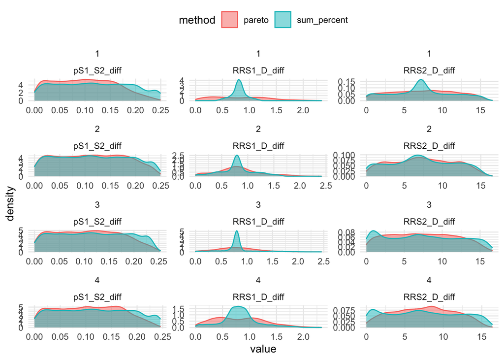

```r
ggplot(ref_df_params_long) +
  geom_density(aes(x = value,col = method,fill = method), alpha = 0.5, position = "identity") +
  # geom_vline(data = inmb_error_abs_means, aes(xintercept = inmb_error_abs, col = method)) +
  facet_wrap(~target_set+variable, ncol = 3, scales = "free") +
  # coord_cartesian(xlim = c(0, 20000)) +
  # xlab("Absolute error in Incremental Net Monetary Benefit") +
  theme_minimal() +
  theme(legend.position = "top")
```

### Pareto Frontier: number of selected parameter sets

The number of selected parameter sets varies considerably, depending on the number of test sets and by random sampling variation. With low numbers of test sets, the Pareto Frontier approach may pccasionally end up selecting just 1 parameter set.

```r
# pareto n size -----
pareto_n_df <- subset(res_mat, method == "pareto")

pareto_n_df_agg <- aggregate(pareto_n ~ n_calib + target_set, pareto_n_df,
          function(x){
            y <- c("mean" = mean(x), "sd" = sd(x), quantile(x, c(0.5, 0.25, 0.75, 0, 1)))
            y <- formatC(y, digits = 0, format = "f", big.mark = ",")
            y <- c(
              "mean (SD)" = paste0(y[1], " (",y[2],")"),
              # "median (IQR)" = paste0(y[3], " (",y[4],"; ",y[5],")")#,
              "range" = paste0("[",y[6], "; ",y[7],"]")
            )
            y})


pareto_n_df_agg <- reshape(pareto_n_df_agg, direction = "wide", timevar = "target_set", idvar = "n_calib")
colnames(pareto_n_df_agg) <- c("n_calib" , paste("Target",1:4))
pareto_n_df_agg
```

```
##   n_calib Target 1.mean (SD) Target 1.range Target 2.mean (SD) Target 2.range
## 1     500             19 (6)        [2; 50]              9 (3)        [1; 24]
## 2    1000             23 (7)        [3; 61]             11 (4)        [1; 28]
## 3    5000            36 (10)        [3; 82]             16 (5)        [4; 40]
## 4   10000            43 (12)       [8; 108]             19 (6)        [3; 44]
## 5   20000            50 (13)       [9; 103]             23 (7)        [3; 54]
## 6   50000            60 (15)      [15; 121]             28 (8)        [5; 66]
##   Target 3.mean (SD) Target 3.range Target 4.mean (SD) Target 4.range
## 1              6 (2)        [1; 19]             23 (7)        [2; 58]
## 2              7 (2)        [1; 18]             29 (9)        [3; 72]
## 3              9 (3)        [1; 20]            50 (14)       [8; 108]
## 4              9 (3)        [2; 22]            61 (17)      [10; 125]
## 5             10 (3)        [2; 22]            74 (19)      [14; 152]
## 6             11 (3)        [2; 27]            92 (23)      [21; 188]
```

# 2.2 SIMULATION STUDY: RANDOM PARAMETER SETS AND UNCERTAIN CALIBRATION TARGETS

## RUN SIMULATION

Consider running this in parallel in the cloud - otherwise, this may take >24h to run.

## ANALYSE RESULTS

### RE-ARRANGE THE DATA

```r
res_uncertain <- data.frame(load_object("./output/res_uncertain.RData")) # couldnt save as rds
for(i in c(1,3:ncol(res_uncertain))){
  res_uncertain[,i] <- as.numeric(res_uncertain[,i])
}
# because of the stochastic ratio target, some results fail with NA outcomes if ratio = 0 or Inf
res_uncertain <- res_uncertain[complete.cases(res_uncertain),]
names(res_uncertain) <- c(
  "run","method","inmb","inmb_error","inmb_error_abs","pareto_diff",
  "pS1_S2_diff", "RRS1_D_diff", "RRS2_D_diff",
  "target_set","pareto_n","n_study_size","true_inmb"
)

res_uncertain <- res_uncertain[res_uncertain$method %in% c("pareto", "sum_percent"),]
dim(res_uncertain)
```

```
## [1] 799874     13
```

```r
head(res_uncertain)
```

```
##   run      method      inmb inmb_error inmb_error_abs pareto_diff  pS1_S2_diff
## 1   1      pareto -62067.38 -19794.930      20056.560     0.00000  0.213622600
## 3   1 sum_percent -83189.63 -40917.180      40917.180 20860.61100  0.246363700
## 4   1      pareto -43562.41  -1289.951       4307.477     0.00000 -0.026622775
## 6   1 sum_percent -44881.45  -2608.998       4344.525    37.04723 -0.008143567
## 7   1      pareto -35032.14   7240.313       7503.171     0.00000 -0.032768660
## 9   1 sum_percent -36243.56   6028.899       6028.899 -1474.27200 -0.034196920
##   RRS1_D_diff RRS2_D_diff target_set pareto_n n_study_size true_inmb
## 1   0.7626147   2.7900669          1     1303         1684 -42272.46
## 3   0.7401651  -2.8526428          1     1303         1684 -42272.46
## 4   0.5599623  -2.7415790          2      105         1684 -42272.46
## 6   0.4616303  -1.6668570          2      105         1684 -42272.46
## 7   0.6783854   0.2797807          3       13         1684 -42272.46
## 9   0.8272466  -0.5224098          3       13         1684 -42272.46
```

```r
# relative performance of pareto vs sum
pareto_diff_abs <- res_uncertain$inmb_error_abs[res_uncertain$method == "pareto"] - res_uncertain$inmb_error_abs[res_uncertain$method == "sum_percent"]
pareto_params_diff_abs <- abs(res_uncertain[res_uncertain$method == "pareto", c("pS1_S2_diff", "RRS1_D_diff", "RRS2_D_diff")]) - abs(res_uncertain[res_uncertain$method == "sum_percent", c("pS1_S2_diff", "RRS1_D_diff", "RRS2_D_diff")])
names(pareto_params_diff_abs)<-paste0("pareto_", names(pareto_params_diff_abs))
overall_diff_df <- res_uncertain[res_uncertain$method == "pareto",]
overall_diff_df$pareto_diff_abs <- pareto_diff_abs
overall_diff_df <- cbind(overall_diff_df,pareto_params_diff_abs)
```

### incrmenetal net monetary benefit - absolute error

```r
# incr NMB --------
aggregate(inmb_error_abs ~ method + target_set, res_uncertain, aggFormat, show_range = T)
```

```
##        method target_set inmb_error_abs.mean (SD) inmb_error_abs.range
## 1      pareto          1           21,095 (8,097)      [1,169; 83,336]
## 2 sum_percent          1          28,185 (14,337)      [2,471; 85,421]
## 3      pareto          2            7,403 (4,151)        [530; 50,891]
## 4 sum_percent          2            5,368 (4,104)        [709; 50,717]
## 5      pareto          3           11,600 (7,032)         [45; 74,814]
## 6 sum_percent          3            7,505 (6,381)      [1,086; 76,271]
## 7      pareto          4           12,461 (5,444)        [819; 61,837]
## 8 sum_percent          4            3,905 (2,859)        [760; 45,646]
```

```r
aggregate(pareto_diff_abs ~ target_set, overall_diff_df, aggFormat, show_range = T)
```

```
##   target_set pareto_diff_abs.mean (SD) pareto_diff_abs.range
## 1          1           -7,091 (14,534)     [-50,094; 73,348]
## 2          2             2,036 (2,854)     [-23,531; 36,500]
## 3          3             4,095 (5,070)     [-17,465; 51,774]
## 4          4             8,556 (5,514)     [-17,590; 55,056]
```

```r
# # true values
# mean(res_t1$true_inmb); sd(res_t1$true_inmb)
```

### calibration parameters - absolute error

```r
# params -----
aggregate(cbind(pS1_S2_diff,RRS1_D_diff,RRS2_D_diff) ~ method + target_set, res_uncertain, aggFormat,digits = 3)
```

```
##        method target_set   pS1_S2_diff   RRS1_D_diff   RRS2_D_diff
## 1      pareto          1 0.114 (0.118) 0.813 (0.524) 3.659 (2.922)
## 2 sum_percent          1 0.169 (0.127) 0.778 (0.199) 0.724 (3.566)
## 3      pareto          2 0.024 (0.133) 0.675 (0.637) 3.574 (4.717)
## 4 sum_percent          2 0.022 (0.136) 0.681 (0.494) 3.574 (4.425)
## 5      pareto          3 0.024 (0.126) 0.733 (0.531) 3.536 (4.501)
## 6 sum_percent          3 0.024 (0.137) 0.710 (0.433) 3.640 (5.226)
## 7      pareto          4 0.049 (0.130) 0.308 (0.486) 3.354 (2.781)
## 8 sum_percent          4 0.026 (0.137) 0.570 (0.436) 3.803 (5.022)
```

```r
aggregate(cbind(pareto_pS1_S2_diff,pareto_RRS1_D_diff,pareto_RRS2_D_diff) ~ method + target_set, overall_diff_df, aggFormat,digits = 3)
```

```
##   method target_set pareto_pS1_S2_diff pareto_RRS1_D_diff pareto_RRS2_D_diff
## 1 pareto          1     -0.045 (0.054)      0.096 (0.396)      1.151 (2.815)
## 2 pareto          2     -0.002 (0.031)      0.050 (0.236)      0.171 (1.888)
## 3 pareto          3     -0.010 (0.022)      0.036 (0.345)     -0.587 (1.538)
## 4 pareto          4      0.002 (0.044)     -0.159 (0.404)     -1.401 (2.625)
```

### Effect of sample size / uncertainty in calibration targets on relative performance of the Pareto Frontier approach compared to the dostance-based score

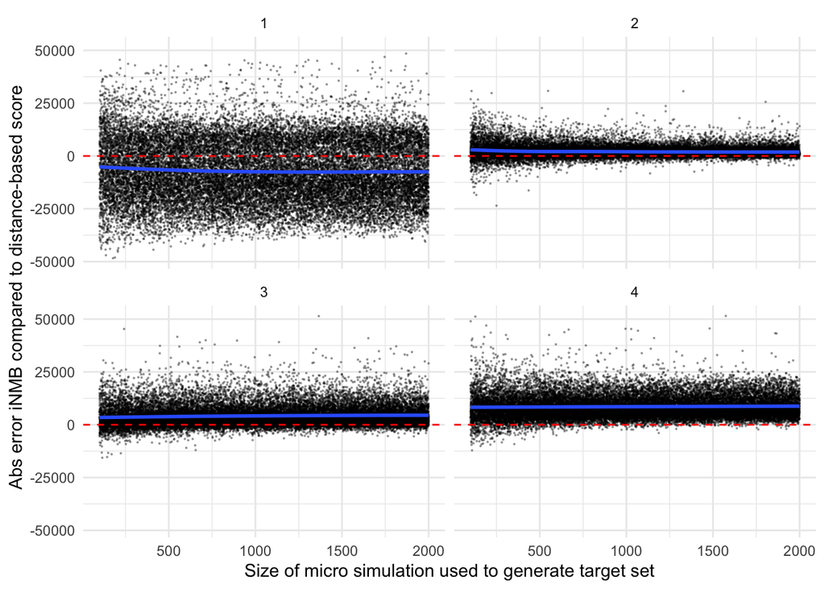

```r
# PLOT
sample_df <- overall_diff_df[sample(1:nrow(overall_diff_df),100000), ] # easier to draw
ggplot(sample_df) +
  geom_point(aes(x=n_study_size, y= pareto_diff_abs), size = 0.1, alpha =0.3) +
  geom_smooth(aes(x=n_study_size, y= pareto_diff_abs), se = T) +
  geom_hline(yintercept = 0, col = "red", linetype = "dashed") +
  facet_wrap(~target_set) +
  xlab("Size of micro simulation used to generate target set") +
  ylab("Abs error iNMB compared to distance-based score") +
  theme_minimal()
```

fin.